# Causal paths and social protection effects

Author

Armando Barrientos

Published

February 27, 2024

```r
library(tidyverse)
library(lme4)
library(fixest)
library(broom)
library(broom.mixed)
library(ggdag)
library(dagitty)
library(ipw)
```

### A simple DAG design to demonstrate alternative associations.

A Directed Acyclic Graph DAG represents graphically the nature of associations between variables in a causal model. Arrows represent causal associations. Causal paths shows associations runnning between multiple variables. Figure 1 deploys associations between a *cause* and an *outcome*, with a *mediator* in between. In addition the graph shows confounders. In the Figure, *conf* represents a common cause, a variable that influences both the *cause* and the *outcome*. A *collider* is a variable which is itself infuenced by both cause and outcome. A variable *z* influences the cause, but no other variable in the graph. The Figures have been constructed using the R DAGgity package (Textor et al. 2017) (a browser based version of [DAGgity](https://dagitty.net/) is also available).

[figure not shown]

Figure 1: A simple DAG to demonstrate associations between variables.

```r
ex1_dag <- dagify(outcome_t ~  mediator_t + conf_t,
                    mediator_t ~ cause_tm1 + conf_t + collider ,
                    collider_t ~ cause_tm1 + outcome_t ,
                    cause_tm1 ~ conf_t + z_tm1,
                    coords = list(x = c(outcome_t = 4, mediator_t = 3, conf_t = 2 ,                                         collider_t = 2, z_tm1 = 1 , cause_tm1 = 1),
                                  y = c(mediator_t = 3,conf_t = 4,collider_t = 1,z_tm1 =2 ,
                                        cause_tm1 = 3, outcome_t = 3)),
                    exposure = "cause_tm1",
                    outcome = "outcome_t")

ggdag_status(ex1_dag, text_col = "black") +
  guides(color = "none") +
  theme_dag()
```

DAGs are underpinned by rules of logic, see (Elwert 2013) and (Igelström et al. 2022) for a short description and discussion. Their advantage is that they help us think through the theoretical basis of the phenomena under investigation. For our purposes, developing a DAG of a social protection model will help us identify and formulate the core hypotheses regarding the stratification effects of social protection emerging from the literature and discussed in Barrientos (2024).

### Applying the simple DAG design to social protection stratification effects.

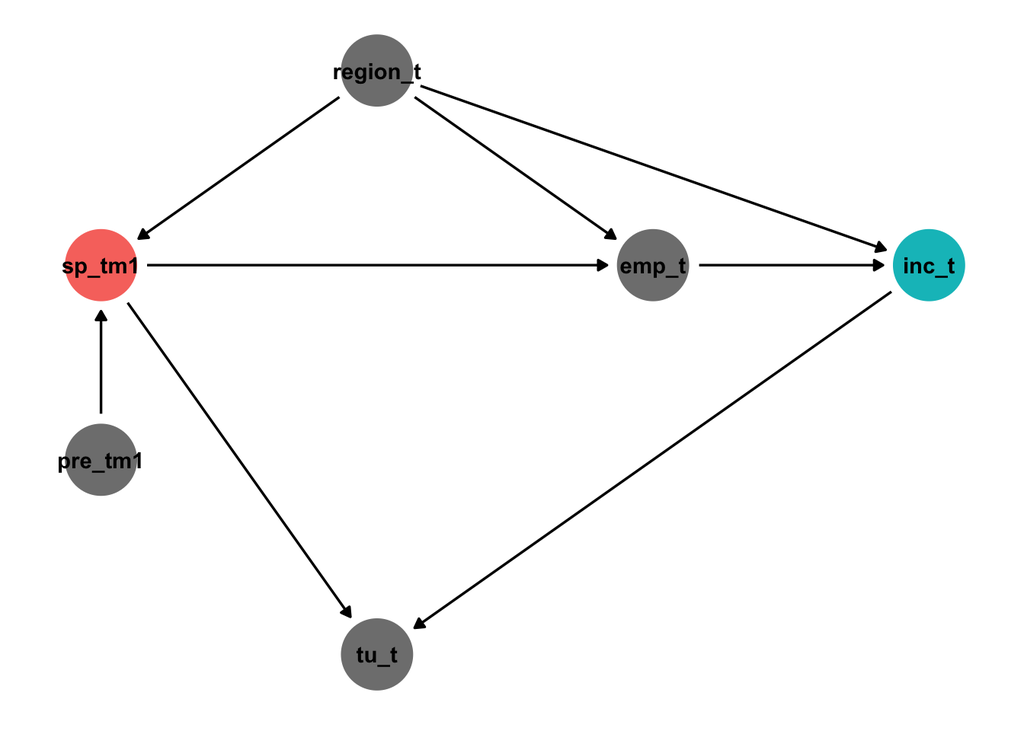

Figure 2: A simple DAG of social protection effects.

```r
sp1_dag <- dagify(inc_t ~ emp_t + region_t,
                   emp_t ~ sp_tm1 + region_t ,
                   tu_t ~ sp_tm1 + inc_t ,
                   sp_tm1 ~ region_t + pre_tm1,
                   coords = list(x = c(inc_t = 4, emp_t = 3, region_t = 2 , tu_t = 2,
                                       pre_tm1 = 1 , sp_tm1 = 1),
                                 y = c(emp_t = 3, region_t = 4, tu_t = 1, pre_tm1 = 2 ,
                                       sp_tm1 = 3, inc_t = 3)),
                   exposure = "sp_tm1",
                   outcome = "inc_t")

ggdag_status(sp1_dag, text_col = "black") +
  guides(color = "none") +
  theme_dag()
```

Social protection, *sp* at time minus 1, institutions influence the *inc*orporation of workers at time t, working through effects on *emp*loyment, the latter figures as a mediator. Note there is also a common cause confounder: *region*. Region membership influences social protection, employment and incorporation. Considering long-term political economy and social protection, countries in Latin America can be grouped into three main regions: Southern early industrialisers, Andean extractive economy countries; and Central American countries. Trade unions *tu* appear in the model as a collider, assumed to be influenced by social protection and by incorporation. Alternative hypotheses in the literature take trade unions as common cause confounders or mediators, especially when explaining the ‘Bismarckian’ character of occupational insurance in the region. Finally, a *pre*-treatment variable is included to capture early influences on the emergence of social protection, such as early industrialisation or integration into the world economy.

There are other DAG features that merit brief reference. The most important feature of DAGs lies in the assumption that variables missing from the model are independent of, do not influence, the treatment and the outcome. What is left out of the model is therefore significant. DAG rules indicate that identification of the causal effects requires accounting for confounders (in this case *region_t*) , but not colliders or pre-treatment variables that do not have influence on both treatment and outcome.

```r
## "The command adjustmentSets identifies variables to be accounted for in the model"

adjustmentSets(sp1_dag)
```

```
{ region_t }
```

### Sequential effects with employment dominant and no confounders.

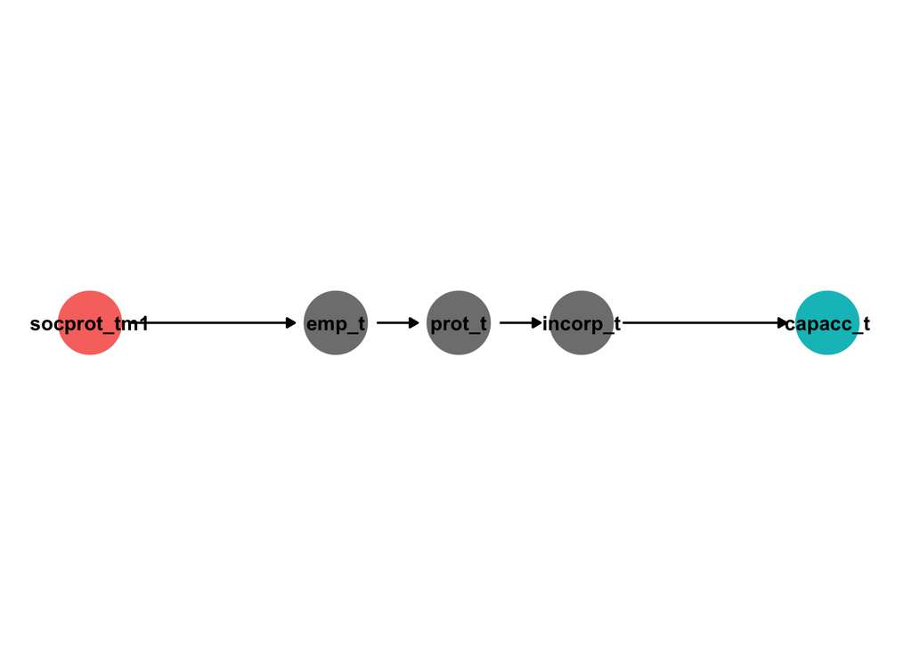

Figure 3: DAG showing sequential social protection stratification effects.

```r
sp11_dag <- dagify(capacc_t ~  incorp_t ,
                    emp_t ~ socprot_tm1 ,
                    prot_t ~ emp_t ,
                    incorp_t ~ prot_t ,
                    coords = list(x = c(capacc_t = 4, emp_t =2, prot_t =2.5 , incorp_t =3,
                                        socprot_tm1 = 1),
                                  y = c(emp_t = 3, prot_t = 3, incorp_t = 3,
                                        socprot_tm1 = 3, capacc_t = 3)),
                    exposure = "socprot_tm1",
                    outcome = "capacc_t")

ggdag_status(sp11_dag, text_col = "black") +
  guides(color = "none") +
  theme_dag()
```

### Independent stratification effects

An alternative model assumes social protection stratification effects to have independent effects on capital accumulation.

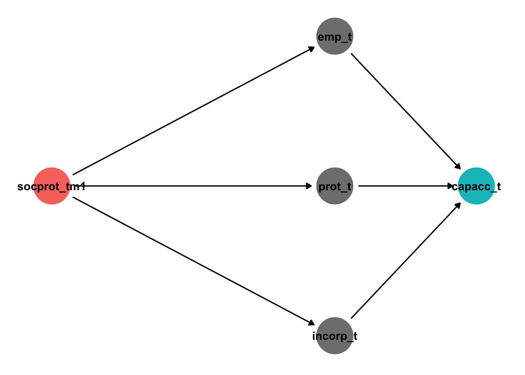

Figure 4: Shows independent effects.

```r
sp12_dag <- dagify(capacc_t ~ emp_t + prot_t + incorp_t,
                    emp_t ~ socprot_tm1 ,
                    prot_t ~ socprot_tm1 ,
                    incorp_t ~ socprot_tm1 ,
                    coords = list(x = c(capacc_t = 4, emp_t = 3, prot_t = 3 , incorp_t = 3,                                        socprot_tm1 = 1),
                                  y = c(emp_t = 4, prot_t = 3, incorp_t = 2,
                                        socprot_tm1 = 3, capacc_t = 3)),
                    exposure = "socprot_tm1",
                    outcome = "capacc_t")

ggdag_status(sp12_dag, text_col = "black") +
  guides(color = "none") +
  theme_dag()
```

### Stratification effects dependence, employment is dominant.

The associations between stratification effects could be hierarchical. Social protection influences employment, protection and incorporation, but in addition protection and incorporation influence employment. There is a direct effect of social protection on employment and indirect effects through protection and incorporation.

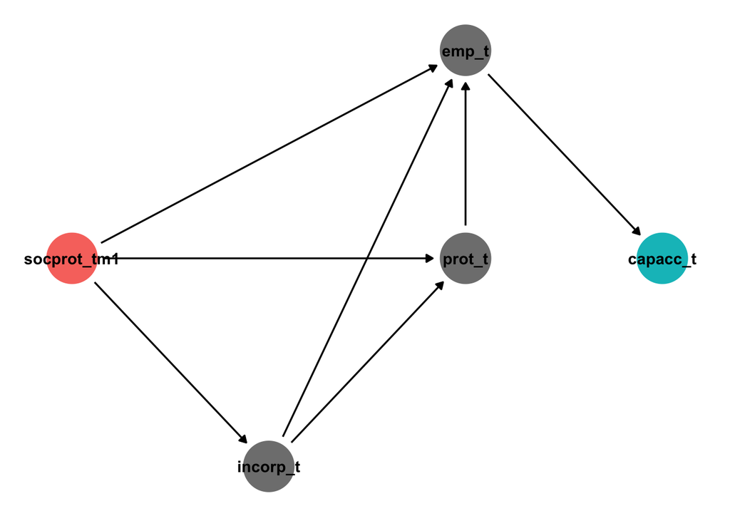

Figure 5: Shows hierrachical dependence of effects.

```r
sp13_dag <- dagify(capacc_t ~ emp_t,
                    emp_t ~ socprot_tm1 + incorp_t + prot_t,
                    prot_t ~ socprot_tm1 + incorp_t ,
                    incorp_t ~ socprot_tm1 ,
                    coords = list(x = c(capacc_t = 4, emp_t = 3, prot_t = 3 , incorp_t = 2,
                                        socprot_tm1 = 1),
                                  y = c(emp_t = 4, prot_t = 3, incorp_t = 2,
                                        socprot_tm1 = 3, capacc_t = 3)),
                    exposure = "socprot_tm1",
                    outcome = "capacc_t")

ggdag_status(sp13_dag, text_col = "black") +
  guides(color = "none") +
  theme_dag()
```

### Dynamic model of stratification effects.

So far we have focused on single period causal models, but it is more realistic to model social protection stratification effects in multiple periods. After all, the focus on institutions is intended to highlight repeated treatments. This adds complexity to the model but matches empirical counterparts in time-series-cross-section or panel data.

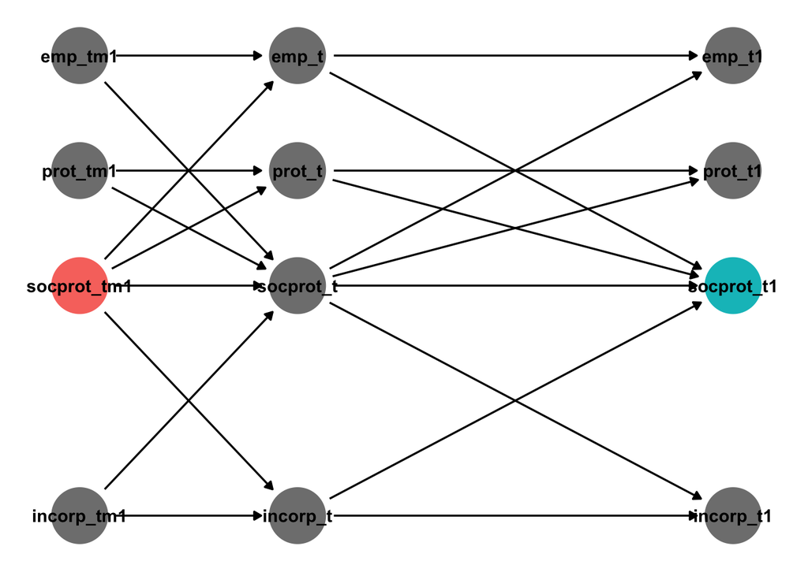

Figure 6: Shows dynamic stratification effects.

```r
sp14_dag <- dagify(socprot_t1 ~ emp_t + prot_t + incorp_t + socprot_t,
                    socprot_t ~ emp_tm1 + prot_tm1 + incorp_tm1 + socprot_tm1,
                    emp_t ~ socprot_tm1 + emp_tm1,
                    emp_t1 ~ socprot_t + emp_t + socprot_t,
                    prot_t ~ socprot_tm1 + prot_tm1,
                    prot_t1 ~ socprot_t + prot_t + socprot_t,
                    incorp_t ~ socprot_tm1 + incorp_tm1,
                    incorp_t1 ~ socprot_t + incorp_t + socprot_t,
                    coords = list(x = c(socprot_t1 = 4, emp_t = 2, prot_t = 2 , incorp_t = 2, emp_t1 = 4, prot_t1 = 4 , incorp_t1 = 4,
                                        socprot_t = 2, socprot_tm1 = 1, emp_tm1=1 , incorp_tm1=1 , prot_tm1 = 1),
                                  y = c(emp_t = 4 , emp_tm1=4 , prot_tm1 = 3.5 , prot_t = 3.5, incorp_tm1=2 , incorp_t = 2 , emp_t1=4 ,prot_t1 = 3.5 , incorp_t1=2 ,
                                        socprot_tm1 = 3, socprot_t = 3, socprot_t1 = 3)),
                    exposure = "socprot_tm1",
                    outcome = "socprot_t1")

ggdag_status(sp14_dag, text_col = "black") +
  guides(color = "none") +
  theme_dag()
```

## References

Elwert, Felix. 2013. “Graphical Causal Models.” In. Dordrecht: Springer. DOI 10.1007/978-94-007-6094-3_13.

Igelström, Erik, Peter Craig, Jim Lewsey, John Lynch, Anna Pearce, and Srinivasa Vittal Katikireddi. 2022. “Causal Inference and Effect Estimation Using Observational Data.” *Journal of Epidemiological Community Health* 76: 960–66. https://doi.org/doi:10.1136/jech-2022-219267.

Textor, Johannes, Benito van der Zander, Mark K. Gilthorpe, Maciej Liskiewicz, and George T. H. Ellison. 2017. “Robust Causal Inference Using Directed Acyclic Graphs: The r Package ’Dagitty’.” *International Journal of Epidemiology* 45 (6): 1887–94. https://doi.org/https://doi.org/10.1093/ije/dyw341.